# **Comorbidity of Depression and Anxiety: Looking at Data on Tech Use and Stress Wellness**

### CMSC320 Fall 2025 Final Project

*Sarah King, Harini Narayanan, Emma Schurr, Akhil Sethukarthy*

[figure not shown]

#### **Contributions**

- **Sarah King**: Introduction section, EDA: Observing the Tech Use and Stress Dataset, Primary Analysis and Visualization: Writing, Formatting, Idea
- **Harini Narayanan**: Data Curation section, EDA: Hypothesis Test 2, EDA: Correlation of age, anxiety, and social media usage
- **Emma Schurr**: Hypothesis Test 1, Primary Analysis and Visualization: Regression and RFE Code, Insights and Conclusions
- **Akhil Sethukarthy**: EDA: statistical test three, Primary Analysis and Visualization: Cluster Maps and Venn Diagram

## **Introduction**

According to Hirschfeld (2001), out of all adults that visit physicians with anxiety and depression, more than 50% of these individuals also have a second anxiety or depression disorder showing that these two emotional disorders are highly comorbid. Across the world, around 359 million people live with anxiety disorders and 280 million live with depression (World Health Organization, 2025). These highly common disorders affect millions of people in their daily lives making it important to identify common issues that can cause these disorders.

Using a dataset on tech use and stress wellness, this project seeks to identify what features are the most important in predicting depression and anxiety. As anxiety and depression are highly co-morbid, this project also seeks to identify whether the features that are important for anxiety and depression overlap.

The questions this project asks are:

1. What features are the most important for predicting anxiety?
2. What features are the most important for predicting depression?
3. Do the features that are the most important for predicting depression overlap with the features that are most important for predicting anxiety?

Citations:

- Hirschfeld, R. M. A. (2001). The Comorbidity of Major Depression and Anxiety Disorders: Recognition and Management in Primary Care. *The Primary Care Companion to the Journal of Clinical Psychiatry*, *3*(6), 244-254. DOI: 10.4088/pcc.v03n0609.
- World Health Organization (2025). *Mental Disorders*. https://www.who.int/news-room/fact-sheets/detail/mental-disorders

## **Data Curation**

We began our data curration by searching for a dataset that outlines many features related to mental health and what causes both anxiety and depression. We found this data set on Kaggle that outlines many features related to mental health and technology use:

https://www.kaggle.com/datasets/nagpalprabhavalkar/tech-use-and-stress-wellness/data

We chose this set because we wanted to gain insights on the comorbidity of anxiety and depression and how tech use affects these conditions in people of different ages. We hypothesized that anxiety and depression are comorbid, meaning they may be caused by the presence or lack of the same features. We also hypothesized that younger generations' mental health are more affected by screen time, and doing exploratory data analysis on this set will allow us to test this hypothesis. This dataset has information about many aspects of one's lifestyle choices and how they impact mental health which we can use to draw conclusions about how they are related.

We evaluated the features of the dataset by organizing the dataset CSV into a readable DataFrame and cleaning the data using Pandas. We then chose the most relevant features of the dataset to conduct our initial exploratory data analysis. These key features included age, location, anxiety score, social media hours, etc.

**Project Setup**

Import packages used for this project

```python
import pandas as pd
import matplotlib.pyplot as plt
import numpy as np
import scipy.stats as stats
from sklearn.linear_model import LinearRegression
from sklearn.feature_selection import RFE
from sklearn.model_selection import train_test_split
from sklearn.metrics import accuracy_score
from sklearn.preprocessing import LabelEncoder
from sklearn.preprocessing import StandardScaler
from sklearn import metrics
from sklearn.metrics import mean_squared_error, mean_absolute_error
from sklearn.feature_selection import RFE
from sklearn.metrics import r2_score
import seaborn as sns
from matplotlib_venn import venn2
```

Load and display database

```python
tech_and_stress_df = pd.read_csv('Tech_Use_Stress_Wellness.csv')
display(tech_and_stress_df.head())
```

|  | user_id | age | gender | daily_screen_time_hours | phone_usage_hours | laptop_usage_hours | tablet_usage_hours | tv_usage_hours | social_media_hours | work_related_hours | ... | stress_level | physical_activity_hours_per_week | location_type | mental_health_score | uses_wellness_apps | eats_healthy | caffeine_intake_mg_per_day | weekly_anxiety_score | weekly_depression_score | mindfulness_minutes_per_day |
| --- | --- | --- | --- | --- | --- | --- | --- | --- | --- | --- | --- | --- | --- | --- | --- | --- | --- | --- | --- | --- | --- |
| 0 | 1 | 53 | Male | 6.8 | 2.9 | 2.1 | 0.5 | 2.0 | 2.3 | 3.0 | ... | 3 | 4.4 | Rural | 79.0 | True | True | 150.4 | 7.0 | 3.0 | 14.0 |
| 1 | 2 | 66 | Female | 4.1 | 2.1 | 1.6 | 0.4 | 0.8 | 2.8 | 3.5 | ... | 4 | 4.1 | Rural | 71.0 | True | True | 124.1 | 7.0 | 10.0 | 15.5 |
| 2 | 3 | 43 | Male | 4.7 | 3.6 | 0.0 | 0.5 | 1.4 | 3.7 | 3.6 | ... | 6 | 1.4 | Urban | 67.0 | True | True | 218.3 | 11.0 | 7.0 | 19.5 |
| 3 | 4 | 29 | Female | 6.0 | 4.5 | 0.0 | 0.2 | 1.3 | 4.5 | 4.0 | ... | 10 | 0.0 | Rural | 55.0 | True | True | 133.7 | 17.0 | 14.0 | 13.9 |
| 4 | 5 | 57 | Male | 6.7 | 3.4 | 2.0 | 0.8 | 1.2 | 3.8 | 3.5 | ... | 6 | 2.8 | Urban | 62.0 | False | False | 192.8 | 5.0 | 8.0 | 26.7 |

5 rows × 25 columns

## **Exploratory Data Analysis**

### **Observing the Tech Use and Stress Dataset**

**Number of rows and columns**

```python
print(tech_and_stress_df.shape)
```

```
(5000, 25)
```

**Column Names/Attributes present**

This dataset encompasses a wide range of attributes that look at tech use and stress wellness such as daily screen time, tv and social media usage, depression, anxiety, eating healthy, etc.

The dataset also includes demographic info such as age, gender, and location that can be used for analysis.

```python
display(tech_and_stress_df.columns)
```

```
Index(['user_id', 'age', 'gender', 'daily_screen_time_hours',
       'phone_usage_hours', 'laptop_usage_hours', 'tablet_usage_hours',
       'tv_usage_hours', 'social_media_hours', 'work_related_hours',
       'entertainment_hours', 'gaming_hours', 'sleep_duration_hours',
       'sleep_quality', 'mood_rating', 'stress_level',
       'physical_activity_hours_per_week', 'location_type',
       'mental_health_score', 'uses_wellness_apps', 'eats_healthy',
       'caffeine_intake_mg_per_day', 'weekly_anxiety_score',
       'weekly_depression_score', 'mindfulness_minutes_per_day'],
      dtype='object')
```

**Column/Attribute Types**

```python
display(tech_and_stress_df.dtypes)
```

|  | 0 |
| --- | --- |
| user_id | int64 |
| age | int64 |
| gender | object |
| daily_screen_time_hours | float64 |
| phone_usage_hours | float64 |
| laptop_usage_hours | float64 |
| tablet_usage_hours | float64 |
| tv_usage_hours | float64 |
| social_media_hours | float64 |
| work_related_hours | float64 |
| entertainment_hours | float64 |
| gaming_hours | float64 |
| sleep_duration_hours | float64 |
| sleep_quality | float64 |
| mood_rating | float64 |
| stress_level | int64 |
| physical_activity_hours_per_week | float64 |
| location_type | object |
| mental_health_score | float64 |
| uses_wellness_apps | bool |
| eats_healthy | bool |
| caffeine_intake_mg_per_day | float64 |
| weekly_anxiety_score | float64 |
| weekly_depression_score | float64 |
| mindfulness_minutes_per_day | float64 |

**dtype:** object

**Missing Values**

None of the columns have any missing information or null values

```python
display(tech_and_stress_df.count())
```

|  | 0 |
| --- | --- |
| user_id | 5000 |
| age | 5000 |
| gender | 5000 |
| daily_screen_time_hours | 5000 |
| phone_usage_hours | 5000 |
| laptop_usage_hours | 5000 |
| tablet_usage_hours | 5000 |
| tv_usage_hours | 5000 |
| social_media_hours | 5000 |
| work_related_hours | 5000 |
| entertainment_hours | 5000 |
| gaming_hours | 5000 |
| sleep_duration_hours | 5000 |
| sleep_quality | 5000 |
| mood_rating | 5000 |
| stress_level | 5000 |
| physical_activity_hours_per_week | 5000 |
| location_type | 5000 |
| mental_health_score | 5000 |
| uses_wellness_apps | 5000 |
| eats_healthy | 5000 |
| caffeine_intake_mg_per_day | 5000 |
| weekly_anxiety_score | 5000 |
| weekly_depression_score | 5000 |
| mindfulness_minutes_per_day | 5000 |

**dtype:** int64

**Unique Values**

The user_id is unique and number of unique values for each column is displayed

```python
display(tech_and_stress_df.nunique())
```

|  | 0 |
| --- | --- |
| user_id | 5000 |
| age | 60 |
| gender | 3 |
| daily_screen_time_hours | 91 |
| phone_usage_hours | 49 |
| laptop_usage_hours | 51 |
| tablet_usage_hours | 29 |
| tv_usage_hours | 41 |
| social_media_hours | 43 |
| work_related_hours | 39 |
| entertainment_hours | 40 |
| gaming_hours | 39 |
| sleep_duration_hours | 36 |
| sleep_quality | 5 |
| mood_rating | 91 |
| stress_level | 10 |
| physical_activity_hours_per_week | 111 |
| location_type | 3 |
| mental_health_score | 69 |
| uses_wellness_apps | 2 |
| eats_healthy | 2 |
| caffeine_intake_mg_per_day | 1885 |
| weekly_anxiety_score | 22 |
| weekly_depression_score | 22 |
| mindfulness_minutes_per_day | 363 |

**dtype:** int64

**Descriptive statistics of numeric values**

Some observations are the mean age is around 44 and the mean daily screen time is around 5 hours with a mean of 2 hours for phone usage.

```python
display(tech_and_stress_df.describe())
```

|  | user_id | age | daily_screen_time_hours | phone_usage_hours | laptop_usage_hours | tablet_usage_hours | tv_usage_hours | social_media_hours | work_related_hours | entertainment_hours | ... | sleep_duration_hours | sleep_quality | mood_rating | stress_level | physical_activity_hours_per_week | mental_health_score | caffeine_intake_mg_per_day | weekly_anxiety_score | weekly_depression_score | mindfulness_minutes_per_day |
| --- | --- | --- | --- | --- | --- | --- | --- | --- | --- | --- | --- | --- | --- | --- | --- | --- | --- | --- | --- | --- | --- |
| count | 5000.000000 | 5000.00000 | 5000.000000 | 5000.000000 | 5000.000000 | 5000.000000 | 5000.000000 | 5000.000000 | 5000.000000 | 5000.000000 | ... | 5000.000000 | 5000.000000 | 5000.000000 | 5000.000000 | 5000.00000 | 5000.000000 | 5000.000000 | 5000.000000 | 5000.000000 | 5000.000000 |
| mean | 2500.500000 | 44.70120 | 5.037860 | 1.994400 | 1.555160 | 0.663060 | 1.433040 | 3.276920 | 3.360240 | 1.662200 | ... | 7.370080 | 4.009400 | 4.447900 | 5.718400 | 2.65934 | 64.766200 | 142.321260 | 8.631800 | 7.520000 | 18.550820 |
| std | 1443.520003 | 17.26688 | 1.835637 | 0.890671 | 1.025994 | 0.525438 | 0.928931 | 1.203655 | 0.827026 | 0.659647 | ... | 0.543875 | 0.663777 | 2.768151 | 2.915064 | 2.28885 | 13.095779 | 50.468392 | 5.092565 | 4.672383 | 7.992543 |
| min | 1.000000 | 15.00000 | 1.000000 | 0.200000 | 0.000000 | 0.000000 | 0.000000 | 0.300000 | 0.700000 | 0.000000 | ... | 5.400000 | 1.000000 | 1.000000 | 1.000000 | 0.00000 | 31.000000 | 0.000000 | 0.000000 | 0.000000 | 5.000000 |
| 25% | 1250.750000 | 30.00000 | 3.700000 | 1.400000 | 0.700000 | 0.200000 | 0.700000 | 2.400000 | 3.100000 | 1.200000 | ... | 7.000000 | 4.000000 | 1.700000 | 3.000000 | 0.60000 | 54.000000 | 108.475000 | 5.000000 | 4.000000 | 12.400000 |
| 50% | 2500.500000 | 45.00000 | 5.000000 | 2.000000 | 1.500000 | 0.600000 | 1.400000 | 3.600000 | 3.700000 | 1.600000 | ... | 7.400000 | 4.000000 | 4.300000 | 6.000000 | 2.30000 | 65.000000 | 141.650000 | 8.000000 | 7.000000 | 17.200000 |
| 75% | 3750.250000 | 60.00000 | 6.300000 | 2.600000 | 2.300000 | 1.000000 | 2.100000 | 4.500000 | 3.900000 | 2.100000 | ... | 7.700000 | 4.000000 | 6.700000 | 8.000000 | 4.20000 | 75.000000 | 176.400000 | 12.000000 | 11.000000 | 23.800000 |
| max | 5000.000000 | 74.00000 | 10.000000 | 5.000000 | 5.000000 | 2.900000 | 4.000000 | 4.500000 | 4.500000 | 3.900000 | ... | 9.000000 | 5.000000 | 10.000000 | 10.000000 | 11.80000 | 100.000000 | 341.200000 | 21.000000 | 21.000000 | 42.000000 |

8 rows × 21 columns

### **Statistical Conclusions**

**Hypothesis Test 1: ANOVA**

The Ho for the ANOVA test for mental health score by location is "there is no relationship between location and mental health score." The Ha is "there is a relationship between location and mental health score."

```python
# ANOVA test for mental health score by location (urban, suburban, rural)
grouped = tech_and_stress_df.groupby('location_type')
urban = grouped.get_group('Urban')["mental_health_score"]
suburban = grouped.get_group('Suburban')["mental_health_score"]
rural = grouped.get_group('Rural')["mental_health_score"]
stat, p = stats.f_oneway(urban, suburban, rural)
print(stat, p)
```

```
2.1434958440945886 0.11735204819958318
```

```python
# Tukey post-hoc tests for each region
urban_suburban = stats.tukey_hsd(urban, suburban)
urban_rural = stats.tukey_hsd(urban, rural)
rural_suburban = stats.tukey_hsd(rural, suburban)
print(urban_suburban, urban_rural, rural_suburban)
```

```
Pairwise Group Comparisons (95.0% Confidence Interval)
Comparison  Statistic  p-value  Lower CI  Upper CI
 (0 - 1)     -0.705     0.101    -1.547     0.137
 (1 - 0)      0.705     0.101    -0.137     1.547
 Pairwise Group Comparisons (95.0% Confidence Interval)
Comparison  Statistic  p-value  Lower CI  Upper CI
 (0 - 1)     -0.840     0.082    -1.787     0.107
 (1 - 0)      0.840     0.082    -0.107     1.787
 Pairwise Group Comparisons (95.0% Confidence Interval)
Comparison  Statistic  p-value  Lower CI  Upper CI
 (0 - 1)      0.134     0.800    -0.908     1.177
 (1 - 0)     -0.134     0.800    -1.177     0.908
```

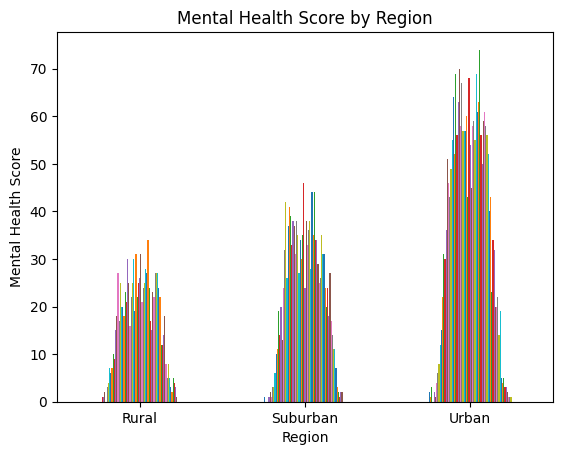

```python
# Bar chart for mental health scores by region
contingency_table = pd.crosstab(tech_and_stress_df['location_type'], tech_and_stress_df['mental_health_score'])
contingency_table.plot(kind='bar', rot=0)
plt.xlabel("Region")
plt.ylabel("Mental Health Score")
plt.title("Mental Health Score by Region")
legend = plt.legend()
legend.set_visible(False)
plt.show()
```

**Hypothesis test 2: Correlation**

```
Pearson's Correlation Coefficient:  0.8089892624587282
```

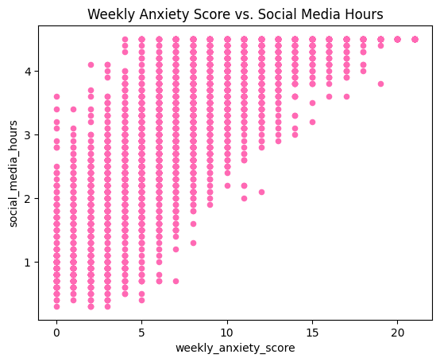

```python
# Hypothesis 2: correlation between weekly anxiety score and social media hours
anxiety_data = tech_and_stress_df['weekly_anxiety_score']
sm_data = tech_and_stress_df['social_media_hours']
correlation = anxiety_data.corr(sm_data)
print("Pearson's Correlation Coefficient: ", correlation)
tech_and_stress_df.plot.scatter(x='weekly_anxiety_score', y='social_media_hours', color='hotpink')
plt.title("Weekly Anxiety Score vs. Social Media Hours")
```

Hypothesis #2: Analysis

Ho = There is no correlation between weekly anxiety score and social media hours.

Ha = There is a signfiicant correlation between weekly anxiety score and social media hours.

**Statisical Test 3: outliers/boxplot**

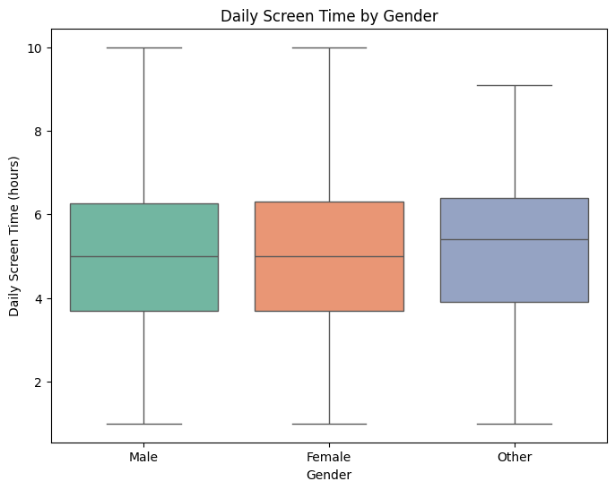

```
Kruskal-Wallis H-statistic: 2.849, p-value: 0.2406
Fail to reject H₀ → No significant difference between genders.
```

```python
data = tech_and_stress_df.dropna(subset=['daily_screen_time_hours', 'gender'])

# Boxplot to visualize outliers
plt.figure(figsize=(8,6))
sns.boxplot(x='gender', y='daily_screen_time_hours', data=data, palette='Set2')
plt.title("Daily Screen Time by Gender")
plt.xlabel("Gender")
plt.ylabel("Daily Screen Time (hours)")
plt.show()

# Kruskal–Wallis test (nonparametric, robust to outliers)
groups = [group["daily_screen_time_hours"].values for name, group in data.groupby("gender")]
stat, p = stats.kruskal(*groups)

print(f"Kruskal-Wallis H-statistic: {stat:.3f}, p-value: {p:.4f}")
if p < 0.05:
    print("Reject H₀ → Significant difference in daily screen time between genders.")
else:
    print("Fail to reject H₀ → No significant difference between genders.")
```

The box-and-whisker plots' whiskers are the barriers of which anything past is an outlier, or 1.5xIQR. We can see that there are no points above or below these barriers, so there are no outliers!

**Correlation of Age, Anxiety, and Social Media Usage**

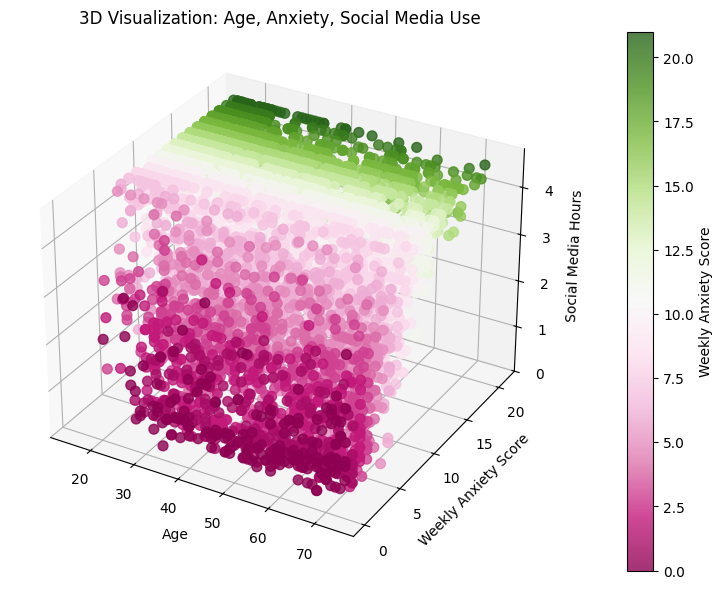

```
                           age  weekly_anxiety_score  social_media_hours
age                   1.000000             -0.375162           -0.382710
weekly_anxiety_score -0.375162              1.000000            0.808989
social_media_hours   -0.382710              0.808989            1.000000
```

```python
# Age vs. Anxiety vs. Social Media Use
import matplotlib.pyplot as plt
import seaborn as sns

fig = plt.figure(figsize=(10,7))
ax = fig.add_subplot(111, projection='3d')

sc = ax.scatter(
    tech_and_stress_df['age'],
    tech_and_stress_df['weekly_anxiety_score'],
    tech_and_stress_df['social_media_hours'],
    c=tech_and_stress_df['weekly_anxiety_score'],
    cmap='PiYG',
    s=50,
    alpha=0.8
)

ax.set_xlabel('Age')
ax.set_ylabel('Weekly Anxiety Score')
ax.set_zlabel('Social Media Hours')
ax.set_title('3D Visualization: Age, Anxiety, Social Media Use')

cbar = plt.colorbar(sc, ax=ax, pad=0.1)
cbar.set_label('Weekly Anxiety Score')

plt.show()

subset_df = tech_and_stress_df[['age', 'weekly_anxiety_score', 'social_media_hours']]

correlation_matrix = subset_df.corr()
print(correlation_matrix)
```

The plot and correlation values clearly show how age, social media hours, and weekly anxiety scores are correlated with one another. We can use this data to analyze larger data sets and possibly use these variables as predictors for one another.

## **Primary Analysis and Visualization**

In order to predict anxiety and depression, we employed multiple linear regression to predict these values. We used multiple regression because we wanted to use multiple features of the dataset to predict continuous values. To prepare our data for linear regression, we converted boolean to numeric values and categorical values to numeric values using label encoding. We dropped columns we thought wouldn’t be relevant to our analysis such as user_id, age, and gender. We also dropped mental health score as we believed it would we be to similar to depression and anxiety so we chose not to include it.

```python
# Depression linear regression
# Change bool columns to type int
tech_and_stress_df['uses_wellness_apps'] = tech_and_stress_df['uses_wellness_apps'].astype(int)
tech_and_stress_df['eats_healthy'] = tech_and_stress_df['eats_healthy'].astype(int)

# Change location type to numeric (label encoding)
le = LabelEncoder()
tech_and_stress_df['location_type'] = le.fit_transform(tech_and_stress_df['location_type'])

# Depression (using linear regression + RFE)
# X = everything but id, age, gender, and mental health score (too similar)
# y = depression score

X = tech_and_stress_df.drop(['user_id', 'age', 'gender', 'mental_health_score'], axis=1)

X_depression = X.drop(['weekly_depression_score'], axis=1)
y_depression = X['weekly_depression_score']

# Standardize Data
X_train, X_test, y_train, y_test = train_test_split(X_depression, y_depression, test_size=0.2, random_state=42)

scaler_X = StandardScaler()
X_train_scaled = scaler_X.fit_transform(X_train)
X_test_scaled  = scaler_X.transform(X_test)

model = LinearRegression()
model.fit(X_train_scaled, y_train)

y_test_pred = model.predict(X_test_scaled)

model_diff = pd.DataFrame({'Depression actual value': y_test,'Depression predicted value': y_test_pred})
display(model_diff)

mae = metrics.mean_absolute_error(y_test, y_test_pred)
mse = metrics.mean_squared_error(y_test, y_test_pred)
r2 = metrics.r2_score(y_test, y_test_pred)

print('Mean Absolute Error:', mae)
print('Mean Square Error:', mse)
print('R2 Score:', r2)
```

|  | Depression actual value | Depression predicted value |
| --- | --- | --- |
| 1501 | 8.0 | 6.435054 |
| 2586 | 7.0 | 7.813393 |
| 2653 | 10.0 | 9.036873 |
| 1055 | 6.0 | 6.339996 |
| 705 | 4.0 | 3.807920 |
| ... | ... | ... |
| 4711 | 14.0 | 11.684920 |
| 2313 | 15.0 | 13.392309 |
| 3214 | 15.0 | 10.539598 |
| 2732 | 8.0 | 11.861164 |
| 1926 | 9.0 | 11.799955 |

1000 rows × 2 columns

```
Mean Absolute Error: 2.172325505105681
Mean Square Error: 7.47237068734341
R2 Score: 0.6369680402778646
```

After training a linear regression model for depression, the R2 score was 0.63 showing that 63% of the variance of depression scores can be explained through multiple linear regression.

In order to answer our questions looking at what features are the most important for predicting depression and anxiety, we used Recursive Feature Elimination (RFE), which works by recursively eliminating the least important features based on model performance. We chose to look at the top 5 most important features.

```
'Selected features:'
```

```
['daily_screen_time_hours',
 'laptop_usage_hours',
 'social_media_hours',
 'sleep_duration_hours',
 'stress_level']
```

```
'R2 on test:'
```

```
0.6371419247856077
```

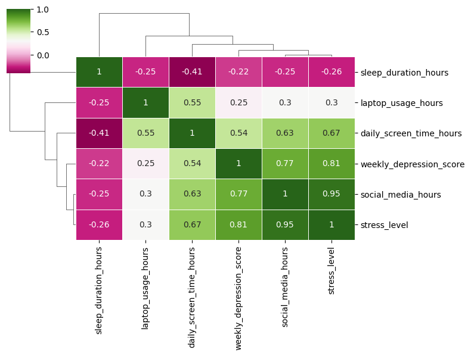

```python
# Depression RFE
# Define the base model
model = LinearRegression()

# Apply RFE
rfe = RFE(estimator=model, n_features_to_select=5)
rfe.fit(X_train_scaled, y_train)

# Predict and evaluate
y_pred = rfe.predict(X_test_scaled)
depression_features = X_depression.columns[rfe.support_]
display("Selected features:", list(depression_features))
display("R2 on test:", r2_score(y_test, y_pred))

# Build correlation matrix for selected features
heatmap = tech_and_stress_df[['weekly_depression_score'] + list(X_depression.columns[rfe.support_])]
corr = heatmap.corr()

# Clustermap
sns.clustermap(
    corr,
    annot=True,
    cmap="PiYG",
    linewidths=.5,
    figsize=(8, 6)
)
```

Using RFE to answer our first question, we found that the top five most important features for predicting depression are daily screen time, laptop usage, social media usage, sleep duration, and stress level. By using a cluster map to visualize correlation, we found that the feature most highly correlated with depression was stress level.

```python
# Anxiety linear regression

# Anxiety (using linear regression + RFE)
# X = everything but id, age, gender, and mental health score (too similar)
# y = anxiety score

X_anxiety = X.drop(['weekly_anxiety_score'], axis=1)
y_anxiety = X['weekly_anxiety_score']

# Standardize Data
X_train, X_test, y_train, y_test = train_test_split(X_anxiety, y_anxiety, test_size=0.2, random_state=42)

scaler_X = StandardScaler()
X_train_scaled = scaler_X.fit_transform(X_train)
X_test_scaled  = scaler_X.transform(X_test)

model = LinearRegression()
model.fit(X_train_scaled, y_train)

y_test_pred = model.predict(X_test_scaled)

model_diff = pd.DataFrame({'Anxiety actual value': y_test,'Anxiety predicted value': y_test_pred})
display(model_diff)

mae = metrics.mean_absolute_error(y_test, y_test_pred)
mse = metrics.mean_squared_error(y_test, y_test_pred)
r2 = metrics.r2_score(y_test, y_test_pred)

print('Mean Absolute Error:', mae)
print('Mean Square Error:', mse)
print('R2 Score:', r2)
```

|  | Anxiety actual value | Anxiety predicted value |
| --- | --- | --- |
| 1501 | 8.0 | 7.547029 |
| 2586 | 9.0 | 9.000883 |
| 2653 | 15.0 | 10.384365 |
| 1055 | 5.0 | 7.032687 |
| 705 | 4.0 | 4.531802 |
| ... | ... | ... |
| 4711 | 16.0 | 13.605387 |
| 2313 | 8.0 | 14.951936 |
| 3214 | 16.0 | 12.310771 |
| 2732 | 20.0 | 13.596848 |
| 1926 | 14.0 | 13.475720 |

1000 rows × 2 columns

```
Mean Absolute Error: 2.1430870896866656
Mean Square Error: 7.207984879221644
R2 Score: 0.7211342755895667
```

After training a linear regression model for anxiety, the R2 score was 0.72 showing the 72% of the variance of anxiety can be explained through multiple linear regression.

```
'Selected features:'
```

```
['phone_usage_hours',
 'social_media_hours',
 'mood_rating',
 'stress_level',
 'location_type']
```

```
'R2 on test:'
```

```
0.7211324560613876
```

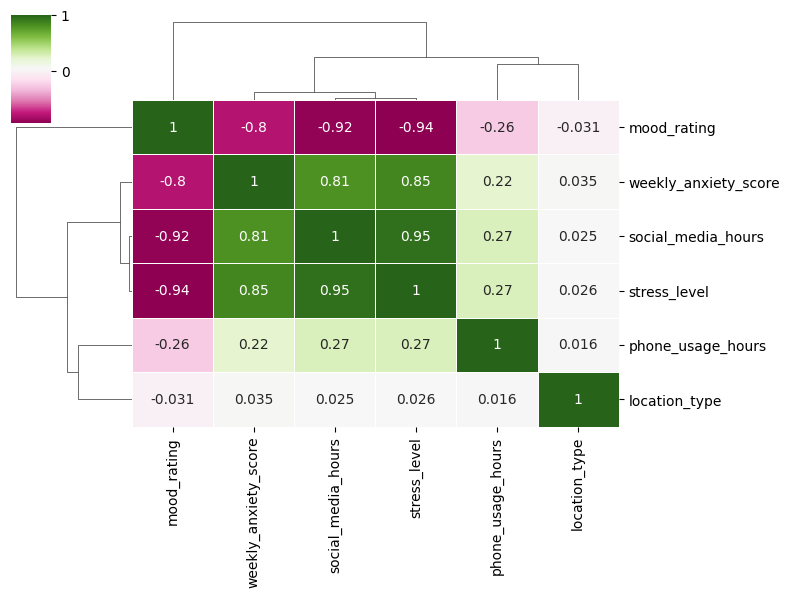

```python
# Build correlation matrix for selected features
# Define the base model
model = LinearRegression()

# Apply RFE
rfe = RFE(estimator=model, n_features_to_select=5)
rfe.fit(X_train_scaled, y_train)

# Predict and evaluate
y_pred = rfe.predict(X_test_scaled)
anxiety_features = X_anxiety.columns[rfe.support_]
display("Selected features:", list(anxiety_features))
display("R2 on test:", r2_score(y_test, y_pred))

# Build correlation matrix for selected features
heatmap = tech_and_stress_df[['weekly_anxiety_score'] + list(X_anxiety.columns[rfe.support_])]
corr = heatmap.corr()

# Clustermap
sns.clustermap(
    corr,
    annot=True,
    cmap="PiYG",
    linewidths=.5,
    figsize=(8, 6)
)
```

Using RFE to answer our second question, we found that the top five most important features for predicting anxiety were phone usage, social media hours, mood rating, stress level, and location type. By using a cluster map to visualize correlation, we found that the feature most highly correlated with anxiety was stress level.

```
Top Anxiety Predictors: Index(['phone_usage_hours', 'social_media_hours', 'mood_rating',
       'stress_level', 'location_type'],
      dtype='object')
Top Depression Predictors: Index(['daily_screen_time_hours', 'laptop_usage_hours', 'social_media_hours',
       'sleep_duration_hours', 'stress_level'],
      dtype='object')
Overlapping Predictors: {'social_media_hours', 'stress_level'}
```

[figure not shown]

```python
print("Top Anxiety Predictors:", anxiety_features)
print("Top Depression Predictors:", depression_features)

# Overlap + venn
overlap = set(anxiety_features) & set(depression_features)
print("Overlapping Predictors:", overlap)

venn2(
    subsets=(len(anxiety_features), len(depression_features), len(overlap)),
    set_labels=("Anxiety Predictors", "Depression Predictors")
)
plt.title("Overlap of Anxiety & Depression Predictive Features")
plt.show()
```

```python
overlap_df = pd.DataFrame(overlap, columns=['Overlapping Features'])
overlap_df
```

|  | Overlapping Features |
| --- | --- |
| 0 | social_media_hours |
| 1 | stress_level |

Our third question asked if the features that are the most important for predicting depression overlap with the features that are most important for predicting anxiety. Based on the previous results, social media usage and stress level were both some of the most important features for predicting anxiety and depression with stress level being the most highly correlated feature for both anxiety and depression. This matches with previous research showing that anxiety and depression are comorbid as based on the machine learning analysis they have some overlapping features.

## **Insights and Conlusions**

After reading through the project, an uninformed reader will know the lifestyle factors that are most likely to affect depression and anxiety, as well as the ages that are most impacted by poor mental health. A reader who already knew the topic would learn that the lifestyle factors that affect depression and anxiety are similar, and decrease overall mental health.

Overall, we can use this data and analysis to inform people, especially 20-30 year olds, about how their lifestyle choices affect their mental health. Educating them will help improve their quality of life, and help them form habits that will lead to a healthier life. Utilizing our Linear Regression Model and Regression Feature Estimation we have been able to predict what the anxiety and depression scores will be, as well as the features that affect it the most.

If we could conduct further research we would examine which social media platforms impact mental health the most. With this data we would be able to determine which social media platforms are the best and worst for mental health. Additionally we would examine which types of physical exercise increase mental health the most.

[figure not shown]